# Assignment Report on MileStone project

Michale Gebrekiros

Wednesday, March 16, 2016

The main objective of the project is to develop a predicting Model. To be able to develop the text model, the following two preliminary analysis will be done

1. Understanding the distribution of the dataset(texts)
2. understanding the relationships between the words, tokens and pharases in the given dataset

```r
setwd("M:/capestone_Project/final/en_US") # to the directory where the dataset is loaded
```

## Load data into RStudio

For explanatory analysis and to understand the freqency distribution of words a sample for the given dataset will be taken as it reduces processing time.

Four folders( de_DE,en_US,fi_FI,ru_RU) containing three files each. One of news, one of blog information, and one from a twitter feed. Since the data sets are very large, a sample at random for each is taken to allow for reasonable processing time and to avoid computing resource issues and a dataset only for en_US is consiederd in this project.

```r
news = readLines("M:/capestone_project/final/en_US/en_US.news.txt")
blogs = readLines("M:/capestone_project/final/en_US/en_US.blogs.txt")
twitter = readLines("M:/capestone_project/final/en_US/en_US.twitter.txt")
```

### Lets take a sample at random for each dataset

25% ,2.5% and 1% of the records were selected randomly for news, blog and twitter data sets respectively.

```r
samplenews <- sample(news, length(news)*0.25)
sampleblogs <- sample(blogs, length(blogs)*0.025)
sampletwitter <- sample(twitter, length(twitter)*0.01)
```

### Let change the data structure into a data frame as follows

```r
snewsDF <- data.frame(charCount=nchar(samplenews), wordCount=sapply(strsplit(samplenews, " "), length))
sblogsDF <- data.frame(charCount=nchar(sampleblogs), wordCount=sapply(strsplit(sampleblogs, " "), length))
stwitterDF <- data.frame(charCount=nchar(sampletwitter), wordCount=sapply(strsplit(sampletwitter, " "), length))
```

### lets observe the heads of the news dataframe

```r
head(snewsDF)
```

```
##   charCount wordCount
## 1       222        36
## 2        37         5
## 3       248        43
## 4       102        17
## 5        22         3
## 6       115        19
```

### lets observe the heads of the blogs dataframe

```r
head(sblogsDF)
```

```
##   charCount wordCount
## 1       291        56
## 2        16         2
## 3       271        49
## 4       279        45
## 5       235        45
## 6        43         7
```

### lets observe the heads of the twitter dataframe

```r
head(stwitterDF)
```

```
##   charCount wordCount
## 1       135        25
## 2        71        13
## 3        39         8
## 4        72        16
## 5       116        20
## 6        29         5
```

### summary of the news,bolg and twitter sample datasets

```r
#Summary for news,blogs and twitter
summary(snewsDF)
```

```
##    charCount      wordCount
##  Min.   :   2   Min.   :   1.00
##  1st Qu.: 110   1st Qu.:  19.00
##  Median : 185   Median :  31.00
##  Mean   : 203   Mean   :  34.19
##  3rd Qu.: 271   3rd Qu.:  46.00
##  Max.   :5760   Max.   :1031.00
```

```r
summary(sblogsDF)
```

```
##    charCount         wordCount
##  Min.   :   2.00   Min.   :   1.00
##  1st Qu.:  46.25   1st Qu.:   8.00
##  Median : 154.00   Median :  28.00
##  Mean   : 231.50   Mean   :  41.49
##  3rd Qu.: 330.00   3rd Qu.:  59.00
##  Max.   :6637.00   Max.   :1133.00
```

```r
summary(stwitterDF)
```

```
##    charCount        wordCount
##  Min.   :  4.00   Min.   : 1.0
##  1st Qu.: 36.00   1st Qu.: 7.0
##  Median : 64.00   Median :12.0
##  Mean   : 68.44   Mean   :12.8
##  3rd Qu.:100.00   3rd Qu.:18.0
##  Max.   :188.00   Max.   :40.0
```

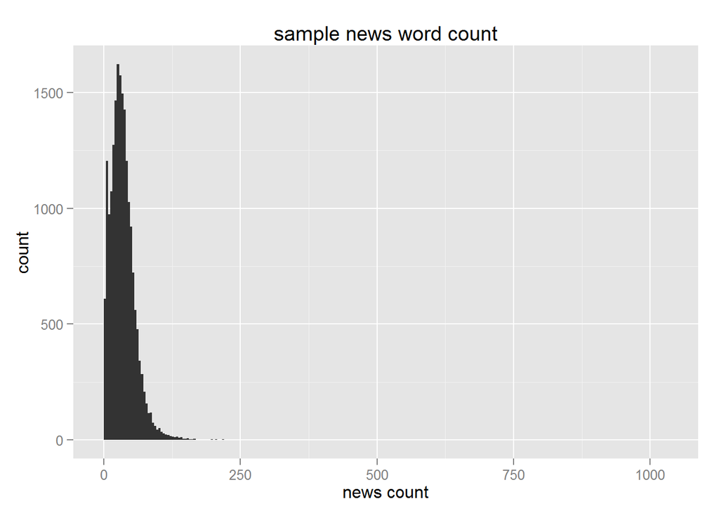

```r
library("ggplot2")

qplot(snewsDF$wordCount,main="sample news word count",binwidth=4,xlab="news count")
```

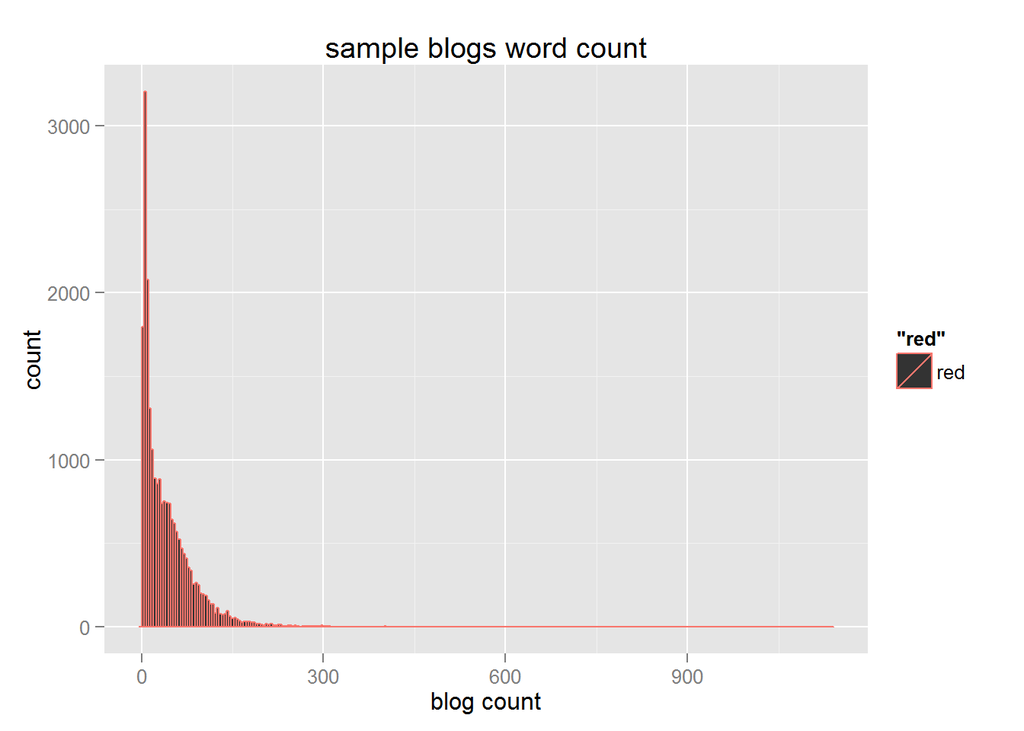

```r
qplot(sblogsDF$wordCount,col="red",main="sample blogs word count",binwidth=4,xlab="blog count")
```

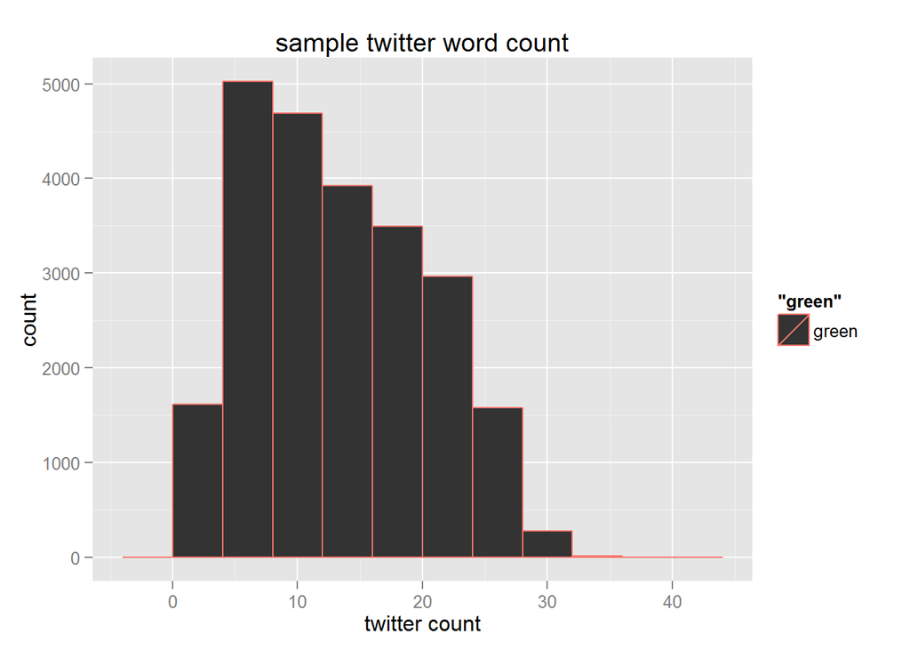

```r
qplot(stwitterDF$wordCount,col="green",main="sample twitter word count",binwidth=4,xlab="twitter count")
```

### Frequency of the words in each texts

To analyze the actual word content, a corpus( a collection of writing ) from the three data sets will be created so word frequency can be determined. Strip out numbers, punctuation, stem words, white space and special characters so just the words are available.

With the corpus, create a DocumentTermMatrix using the TM package. Strip sparse terms. Orient for the most frequent words, and list them for review to illustrate the counts of the most frequently found words in the corpus.

```r
library("tm")
corpus <- c(samplenews,sampleblogs,sampletwitter)
corpus <- Corpus(VectorSource(corpus))
```

Building the corpus, removing numbers, whitespaces, special characters and lowercasing all contents.

```r
corpus  <- tm_map(corpus,tolower)
corpus  <- tm_map(corpus,removePunctuation)
corpus  <- tm_map(corpus,removeNumbers)
corpus  <- tm_map(corpus,stemDocument)
corpus  <- tm_map(corpus,stripWhitespace)
corpus  <- tm_map(corpus, PlainTextDocument)
```

Tokenizing corpus into matrix by using DocumentTermMatrix.

```r
dtm_samples = DocumentTermMatrix(corpus)
```

```r
dtm_samples1 <- removeSparseTerms(dtm_samples, 0.98)

freq <- sort (colSums (as.matrix(dtm_samples1)), decreasing =TRUE)
wordsf <- data.frame (word=names(freq), freq=freq)

wordsf1 <- wordsf[1:30,]
wordsf1
```

```
##        word  freq
## the     the 92999
## and     and 48551
## that   that 20290
## for     for 19667
## you     you 14430
## with   with 13757
## was     was 12473
## this   this 10199
## have   have  9793
## but     but  9193
## are     are  9031
## not     not  7813
## from   from  7388
## they   they  6321
## his     his  6013
## said   said  5898
## all     all  5847
## will   will  5769
## about about  5553
## one     one  5375
## out     out  5206
## its     its  5170
## has     has  5095
## just   just  4916
## what   what  4901
## your   your  4789
## when   when  4748
## who     who  4735
## had     had  4618
## can     can  4537
```

### The most frequent words

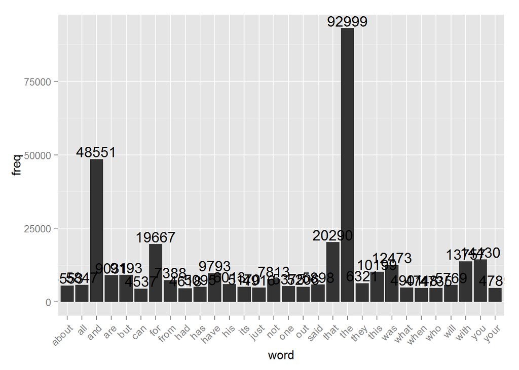

```r
ggplot(wordsf1, aes(word, freq)) +  geom_bar(stat="identity") + theme(axis.text.x=element_text(angle=45, hjust=1))+geom_text(aes(label=freq), vjust=-0.2)
```

### The Prediction Model

Developing on the frequency characteristics described above, the plan will be to extend the use of the TM library to build n-grams of 2 or 3 words, generated from the data. These n-grams will be used to develop the predictive model. The basic idea will be to use a entered word to find the most likely n-gram (of 2 or more) starting with that word.

Using the n-grams, the Shiny app will accept input and evaluate the input per the created n-grams in order to predict words most likely to follow the entered word using regular expresssions or similar coding techniques.

The Shiny App will display an text input box, allowing for data entry. The output will consist of a list of words per the evaluation of the n-grams.